# Coursera Data Products Course Assignment

July 1, 2018

## Purpose

- The purpose of this assignment is to provide a pitch for the Shiny web application that has been developed.
- It will contain the methodology and the benifits of shiny and the application in question.

### Description

- There are instances where a bilinear model fit is a good starting point in data analysis. This however needs the selection of a knee point. The aim of this application is to ease the selection of the knee point and get to it interactively.
- There are 3 main parts to the application:
  - The data generation (The user can vary parameters to get data of choice) & variable interaction
  - The knee point selection using the slider, here the user specifies the exact knee point to be used.
  - The knee point selection using brush selection and a clustering algorithm
- A screen shot of the UI hosted on Shiny server is on the last page to familiarize the user with the interface.

## Data Generation

- Here we see the 3 possible relationships in the data the user can explore. The radio buttons in the application can toggle the different intervariable relationships.
- There is also the functionality to invert the slopes, increase and decrease the noise in the data and the maximum limits of the plots.

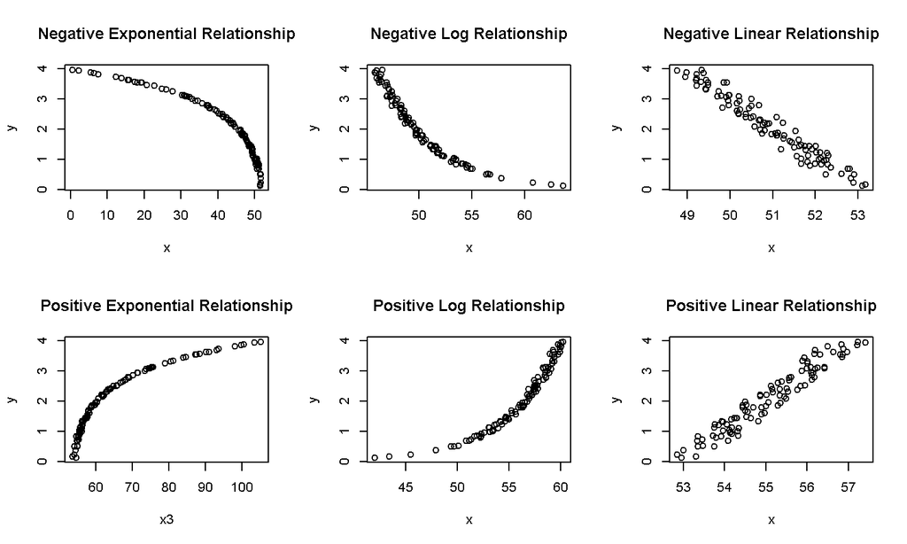

## Model Fitting

- We fit two models for the data. A linear model in red & a bilinear model in blue.
- The knee point value has been parameterized (as a slider) for the user to hone in on the best knee value for the best fit.

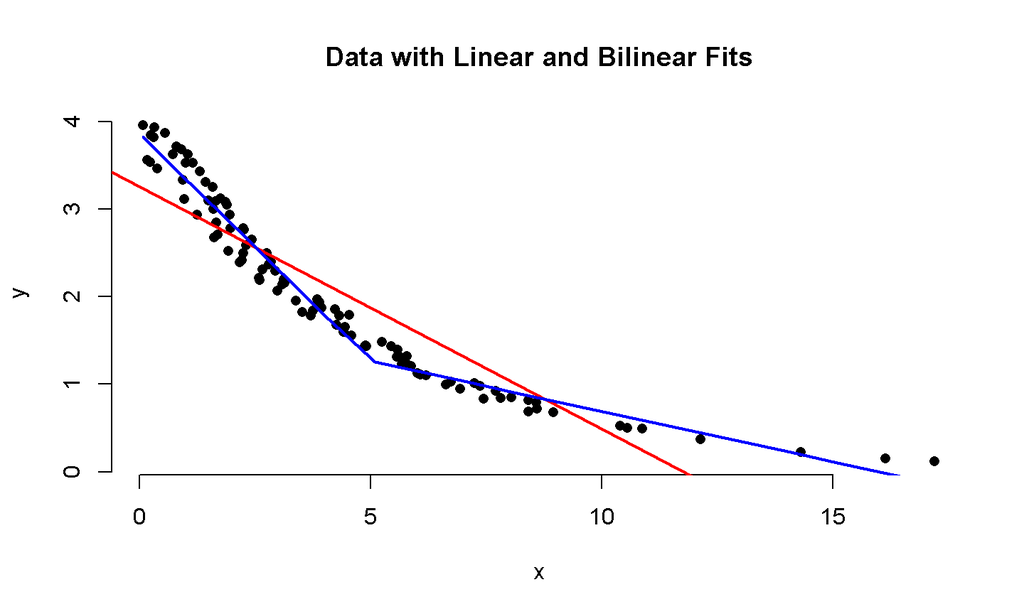

## Clustering using brushpoints

- Sometimes its easier visually to pickout the greatest mass in the data that might contain the knee point.
- Inorder to do so, we use the brush points method (in shiny) to select the best section within which the knee point resides.
- A clustering algorithm is used to select the medoid of the data, this is used as the knee point in ensuing calculations.
- This example shows the working of the clustering algorithm to select the mediod of the data in red.

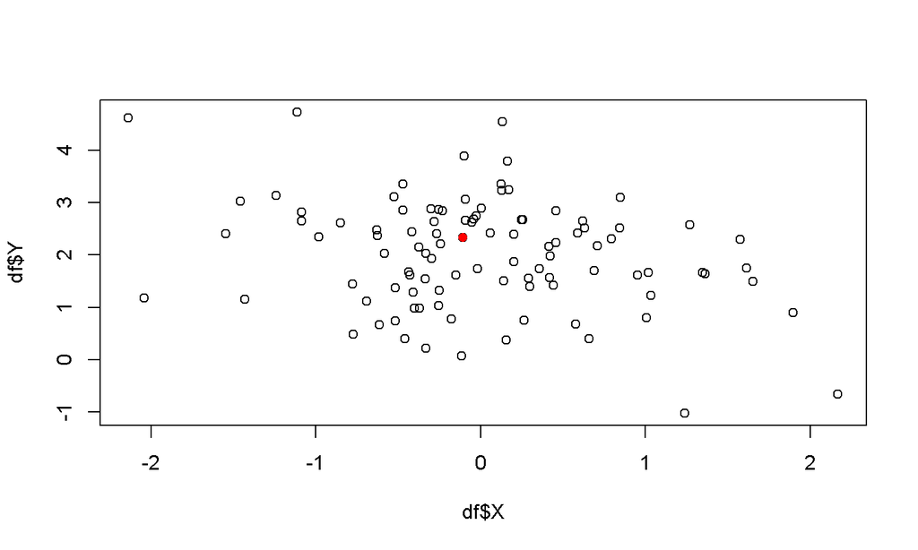

## Putting it all together

Thank you.

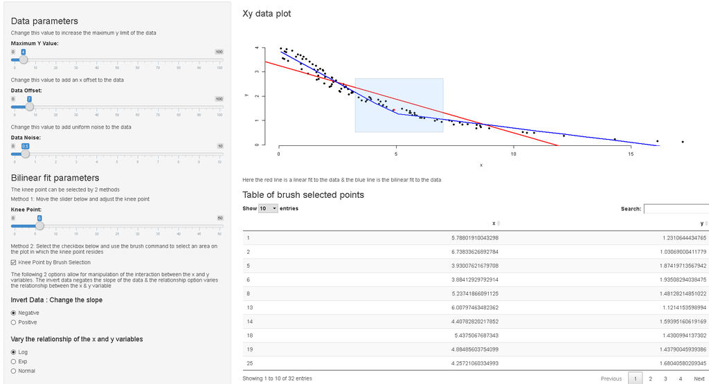

Shiny Applcation UI

Thank you